# Regresión simple y múltiple dataset FIFA

Jonatan Zabala

[figure not shown]

Descripción del Dataset.

El dataset “caso” utilizado para el desarrollo de este taller, incluye los datos de los jugadores del videojuego de simulación de fútbol FIFA desarrollado por EA Sports (electronic arts), disponible para las plataformas de videojuegos de PlayStation y Xbox principalmente.

Este dataset extraído de la plataforma Kaggle está compuesto de 18 variables y 150 registros. De las cuales 15 variables son cuantitativas o numéricas y 3 variables son categóricas o cualitativas.

Entre las variables categóricas encontramos datos como el club en el cual milita el jugador, el pie más hábil y su posición dentro del equipo. Por otro lado, entre las variables numéricas encontramos datos como edad, estatura, peso en kg, entre otras variables que describiremos a continuación.

Librerías.

```r
library(readr)
library(dplyr)
library(ggplot2)
library(shiny)
library(fdth)
library(nortest)
library(PASWR2)
library(lmtest)
library(car)
library(GGally)
library(psych)
library(corrplot)
library(MASS)
library(trafo)
library(gridExtra)
```

# PARTE 1. Exploración.

## 1.Utilice el dataset: caso

## 2. Defina las siguientes variables que aparecen en el dataset

Definición de las variables.

- **club:** Variable categórica que define el club al cual pertenece el jugador.
- **preferred_foot:** Variable categórica, muestra el pié más hábil del jugador, si es derecho *Right* o izquierdo *Left*
- **team_position:** Variable categórica que define la posición del jugador en el equipo. Existen 19 posiciones diferentes, entre las cuales tenemos:
- **age:** Variable numérica que indica la edad del jugador.
- **height_cm:** Variable que se refiere a la estatura en centímetros del jugador.
- **weight_kg:** Variable numérica, se refiere al peso en kilogramos del jugador.
- **overall:** Variable numérica, calificación general del jugador.
- **potential:** Variable numérica, mide el potencial de cada jugador para ser considerado de la siguiente manera: “Mostrar un gran potencial” significa que un jugador crecerá hasta un máximo de 80-84, “una proyección emocionante” alcanzará los 85-89 y un jugador etiquetado como “tiene potencial para ser especial” llegará a 90 o más.
- **value_eur:** Variable en formato numérico que significa el valor económico de un jugador.
- **wage_eur:** Variable numérica que significa salario del jugador.
- **release_clause_eur:** Variable en formato numérico, básicamente es una cláusula insertada en el contrato de un jugador que permite que otros clubes intenten fichar a ese jugador. Siempre y cuando, por supuesto, cumplan con el monto de la cláusula.
- **shooting:** Variable numérica que mide las habilidades de tiro, entre estas habilidades de tiro se encuentran definición, potencia de tiro, voleas, tiro lejano, penales entre otras.
- **passing:** Variable numérica que mide la capacidad del jugador de realizar pases efectivos, entre las habilidades destacadas se halla la visión, centros, precisión de tiros libres, pase corto y largo, curva.
- **dribbling:** Variable numérica, mide el regate o la capacidad de un jugador de superar al jugador adversario desde diferentes perspectivas; tales como, agilidad, balance, reacción, control de balón.
- **defending:** Variable numérica que mide la capacidad del jugador de defender la posición y obtener el dominio del balón, entre las habilidades del defensor se encuentran las intercepciones, cabezazo, marcaje, entrada limpia, barrida.
- **physic:** Variable numérica que mide en un jugador la fuerza, el salto, la energía, agresión.
- **pace:** Variable numérica que mide la velocidad del jugador bajo los siguientes criterios: aceleración y velocidad final.

Fuente: **GUIA DE ATRIBUTOS – FIFA ULTIMATE TEAM** Tomado de: https://www.todoultimateteam.com/guia-de-atributos-fifa-ultimate-team/

Exploración del Dataset.

Procedemos a realizar una exploración rápida del dataset

```r
head(caso,5);
```

```
## # A tibble: 5 × 18
##    ...1 club       prefe…¹ team_…²   age heigh…³ weigh…⁴ overall poten…⁵ value…⁶
##   <dbl> <chr>      <chr>   <chr>   <dbl>   <dbl>   <dbl>   <dbl>   <dbl>   <dbl>
## 1     1 Eintracht… Right   RES        19     182      75      59      75  325000
## 2     2 Sarpsborg… Right   RES        21     180      75      56      63  130000
## 3     3 SC Heeren… Right   SUB        21     193      77      69      76 1500000
## 4     4 FC Bayern… Right   SUB        19     175      72      61      78  500000
## 5     5 Atlético … Right   RES        23     179      71      58      64  150000
## # … with 8 more variables: wage_eur <dbl>, release_clause_eur <dbl>,
## #   shooting <dbl>, passing <dbl>, dribbling <dbl>, defending <dbl>,
## #   physic <dbl>, pace <dbl>, and abbreviated variable names ¹preferred_foot,
## #   ²team_position, ³height_cm, ⁴weight_kg, ⁵potential, ⁶value_eur
```

```r
tail(caso,5)
```

```
## # A tibble: 5 × 18
##    ...1 club       prefe…¹ team_…²   age heigh…³ weigh…⁴ overall poten…⁵ value…⁶
##   <dbl> <chr>      <chr>   <chr>   <dbl>   <dbl>   <dbl>   <dbl>   <dbl>   <dbl>
## 1   146 FC Rostov  Right   RCM        33     190      80      72      72  1.8 e6
## 2   147 Real Spor… Right   RES        20     191      83      63      70  5.25e5
## 3   148 Cagliari   Right   SUB        24     187      80      68      74  1.2 e6
## 4   149 Real Betis Right   LM         25     178      65      77      78  1.05e7
## 5   150 Sheffield… Right   RS         29     175      71      73      73  4   e6
## # … with 8 more variables: wage_eur <dbl>, release_clause_eur <dbl>,
## #   shooting <dbl>, passing <dbl>, dribbling <dbl>, defending <dbl>,
## #   physic <dbl>, pace <dbl>, and abbreviated variable names ¹preferred_foot,
## #   ²team_position, ³height_cm, ⁴weight_kg, ⁵potential, ⁶value_eur
```

```r
str(caso)
```

```
## spc_tbl_ [150 × 18] (S3: spec_tbl_df/tbl_df/tbl/data.frame)
##  $ ...1              : num [1:150] 1 2 3 4 5 6 7 8 9 10 ...
##  $ club              : chr [1:150] "Eintracht Braunschweig" "Sarpsborg 08 FF" "SC Heerenveen" "FC Bayern München" ...
##  $ preferred_foot    : chr [1:150] "Right" "Right" "Right" "Right" ...
##  $ team_position     : chr [1:150] "RES" "RES" "SUB" "SUB" ...
##  $ age               : num [1:150] 19 21 21 19 23 21 28 23 29 23 ...
##  $ height_cm         : num [1:150] 182 180 193 175 179 193 183 181 182 198 ...
##  $ weight_kg         : num [1:150] 75 75 77 72 71 86 76 74 81 93 ...
##  $ overall           : num [1:150] 59 56 69 61 58 58 65 68 72 71 ...
##  $ potential         : num [1:150] 75 63 76 78 64 65 66 77 72 75 ...
##  $ value_eur         : num [1:150] 325000 130000 1500000 500000 150000 180000 500000 1400000 2400000 3100000 ...
##  $ wage_eur          : num [1:150] 2000 1000 5000 7000 1000 1000 3000 22000 12000 11000 ...
##  $ release_clause_eur: num [1:150] 723000 189000 2500000 1100000 255000 261000 838000 2800000 4600000 4900000 ...
##  $ shooting          : num [1:150] 60 43 64 41 28 58 53 59 56 69 ...
##  $ passing           : num [1:150] 56 51 61 57 33 37 55 69 69 55 ...
##  $ dribbling         : num [1:150] 62 57 67 66 37 45 55 65 64 63 ...
##  $ defending         : num [1:150] 21 42 53 58 62 22 63 57 73 29 ...
##  $ physic            : num [1:150] 56 69 74 59 56 73 63 65 71 76 ...
##  $ pace              : num [1:150] 69 78 60 62 54 50 60 65 62 66 ...
##  - attr(*, "spec")=
##   .. cols(
##   ..   ...1 = col_double(),
##   ..   club = col_character(),
##   ..   preferred_foot = col_character(),
##   ..   team_position = col_character(),
##   ..   age = col_double(),
##   ..   height_cm = col_double(),
##   ..   weight_kg = col_double(),
##   ..   overall = col_double(),
##   ..   potential = col_double(),
##   ..   value_eur = col_double(),
##   ..   wage_eur = col_double(),
##   ..   release_clause_eur = col_double(),
##   ..   shooting = col_double(),
##   ..   passing = col_double(),
##   ..   dribbling = col_double(),
##   ..   defending = col_double(),
##   ..   physic = col_double(),
##   ..   pace = col_double()
##   .. )
##  - attr(*, "problems")=<externalptr>
```

```r
summary(caso)
```

```
##       ...1            club           preferred_foot     team_position
##  Min.   :  1.00   Length:150         Length:150         Length:150
##  1st Qu.: 38.25   Class :character   Class :character   Class :character
##  Median : 75.50   Mode  :character   Mode  :character   Mode  :character
##  Mean   : 75.50
##  3rd Qu.:112.75
##  Max.   :150.00
##       age          height_cm       weight_kg        overall
##  Min.   :18.00   Min.   :162.0   Min.   :57.00   Min.   :49.00
##  1st Qu.:21.00   1st Qu.:176.2   1st Qu.:71.25   1st Qu.:61.25
##  Median :24.00   Median :181.0   Median :75.00   Median :66.00
##  Mean   :24.79   Mean   :180.9   Mean   :74.83   Mean   :66.17
##  3rd Qu.:28.00   3rd Qu.:185.0   3rd Qu.:79.00   3rd Qu.:71.00
##  Max.   :35.00   Max.   :198.0   Max.   :93.00   Max.   :83.00
##    potential       value_eur           wage_eur      release_clause_eur
##  Min.   :58.00   Min.   :   50000   Min.   :  1000   Min.   :  104000
##  1st Qu.:68.00   1st Qu.:  375000   1st Qu.:  2000   1st Qu.:  675000
##  Median :72.00   Median :  712500   Median :  4000   Median : 1200000
##  Mean   :71.57   Mean   : 2097400   Mean   : 10573   Mean   : 3883287
##  3rd Qu.:75.00   3rd Qu.: 2000000   3rd Qu.: 12000   3rd Qu.: 3675000
##  Max.   :86.00   Max.   :24000000   Max.   :130000   Max.   :46200000
##     shooting        passing        dribbling       defending
##  Min.   :18.00   Min.   :25.00   Min.   :28.00   Min.   :19.00
##  1st Qu.:41.00   1st Qu.:49.25   1st Qu.:56.00   1st Qu.:30.25
##  Median :55.00   Median :57.00   Median :64.00   Median :53.50
##  Mean   :52.44   Mean   :56.86   Mean   :61.91   Mean   :48.92
##  3rd Qu.:63.00   3rd Qu.:65.75   3rd Qu.:68.00   3rd Qu.:65.00
##  Max.   :78.00   Max.   :78.00   Max.   :85.00   Max.   :80.00
##      physic           pace
##  Min.   :33.00   Min.   :32.00
##  1st Qu.:58.00   1st Qu.:62.00
##  Median :65.00   Median :69.00
##  Mean   :64.86   Mean   :68.37
##  3rd Qu.:72.00   3rd Qu.:75.00
##  Max.   :85.00   Max.   :92.00
```

Observaremos ahora si existen variables con datos faltantes.

```r
sapply(caso, function(x) sum(is.na(x)))
```

```
##               ...1               club     preferred_foot      team_position
##                  0                  0                  0                  0
##                age          height_cm          weight_kg            overall
##                  0                  0                  0                  0
##          potential          value_eur           wage_eur release_clause_eur
##                  0                  0                  0                  0
##           shooting            passing          dribbling          defending
##                  0                  0                  0                  0
##             physic               pace
##                  0                  0
```

Dado lo anterior, podemos evidenciar que el dataset caso no contiene datos faltantes o NA.

# PARTE 2: Regresión Lineal Simple

Extracción de la muestra con 130 datos.

## 1. Dataframe ‘aleatorio’.

Procedemos a crear un dataset llamado *aleatorio* con 130 datos aleatorios extraídos del dataset **caso**, instalado anteriormente.

```r
set.seed(2)
caso1 <- sample(1:nrow(caso), 130)
aleatorio <- caso[caso1, ]
aleatorio
```

```
## # A tibble: 130 × 18
##     ...1 club      prefe…¹ team_…²   age heigh…³ weigh…⁴ overall poten…⁵ value…⁶
##    <dbl> <chr>     <chr>   <chr>   <dbl>   <dbl>   <dbl>   <dbl>   <dbl>   <dbl>
##  1    85 SC Preuß… Right   SUB        19     180      75      60      74  450000
##  2     6 Ventfore… Right   RES        21     193      86      58      65  180000
##  3   136 Deportiv… Left    SUB        32     176      69      74      74 4400000
##  4    17 Seattle … Right   RES        21     183      77      62      70  450000
##  5    93 Pogoń Sz… Right   LCB        22     191      80      67      77 1100000
##  6   125 Girona FC Right   LM         26     176      72      73      76 4900000
##  7    41 FC St. P… Right   SUB        24     183      71      67      71 1000000
##  8    75 Göztepe … Left    SUB        23     167      61      63      70  525000
##  9   131 Borussia… Right   LDM        20     191      80      72      86 7000000
## 10    50 Rangers … Right   RCM        25     182      72      73      75 4100000
## # … with 120 more rows, 8 more variables: wage_eur <dbl>,
## #   release_clause_eur <dbl>, shooting <dbl>, passing <dbl>, dribbling <dbl>,
## #   defending <dbl>, physic <dbl>, pace <dbl>, and abbreviated variable names
## #   ¹preferred_foot, ²team_position, ³height_cm, ⁴weight_kg, ⁵potential,
## #   ⁶value_eur
```

Ahora, al dataset **caso**, le quitamos las filas del dataset *aleatorio* y generamos un nuevo dataset con esta información denominado *prueba* compuesto por las 20 observaciones restantes.

```r
prueba <- caso[-caso1, ]
prueba
```

```
## # A tibble: 20 × 18
##     ...1 club      prefe…¹ team_…²   age heigh…³ weigh…⁴ overall poten…⁵ value…⁶
##    <dbl> <chr>     <chr>   <chr>   <dbl>   <dbl>   <dbl>   <dbl>   <dbl>   <dbl>
##  1    10 KV Ooste… Left    ST         23     198      93      71      75 3100000
##  2    16 Trabzons… Right   SUB        25     173      74      69      73 1100000
##  3    30 SD Eibar  Right   SUB        33     177      75      77      77 5500000
##  4    31 Daegu FC  Left    SUB        24     177      74      65      69  600000
##  5    34 Perth Gl… Right   SUB        27     175      70      62      62  260000
##  6    39 Atiker K… Right   RES        23     173      66      58      63  170000
##  7    40 FC Anzhi… Right   RM         26     181      74      72      73 3700000
##  8    52 Kilmarno… Right   SUB        19     178      70      53      68  110000
##  9    59 Stabæk F… Right   SUB        22     181      75      64      71  625000
## 10    60 GwangJu … Right   SUB        23     172      64      53      61   90000
## 11    73 Real Val… Left    RES        21     176      72      61      69  375000
## 12    76 Envigado… Left    RES        19     185      79      56      72  170000
## 13    89 AFC Wimb… Right   SUB        18     183      69      56      68  130000
## 14   107 FC Dallas Right   RM         26     162      59      73      74 4700000
## 15   116 AEK Athe… Right   SUB        27     177      74      75      76 7500000
## 16   117 Blackpool Right   RES        18     188      80      51      72   80000
## 17   120 VfB Stut… Left    LDM        22     172      70      73      81 6000000
## 18   139 Gimnasia… Right   SUB        21     183      78      61      68  350000
## 19   143 1. FSV M… Right   RES        19     174      68      57      77  220000
## 20   145 PFC CSKA… Right   LDM        31     187      85      79      79 8500000
## # … with 8 more variables: wage_eur <dbl>, release_clause_eur <dbl>,
## #   shooting <dbl>, passing <dbl>, dribbling <dbl>, defending <dbl>,
## #   physic <dbl>, pace <dbl>, and abbreviated variable names ¹preferred_foot,
## #   ²team_position, ³height_cm, ⁴weight_kg, ⁵potential, ⁶value_eur
```

Análisis dataframe ‘aleatorio’.

## 2. Análisis regresión variables shooting y dribbling.

A continuación procedemos a realizar el análisis de **Regresión Lineal Simple** a partir del dataset *aleatorio* con las variables **(x=shooting y y=dribbling)**:

Ponemos estas variables en una tabla: data.frame

```r
regresion_simple <- data.frame(aleatorio$shooting, aleatorio$dribbling); t(regresion_simple)
```

```
##                     [,1] [,2] [,3] [,4] [,5] [,6] [,7] [,8] [,9] [,10] [,11]
## aleatorio.shooting    52   58   67   54   32   69   54   47   40    54    49
## aleatorio.dribbling   63   45   77   61   38   74   74   64   72    69    62
##                     [,12] [,13] [,14] [,15] [,16] [,17] [,18] [,19] [,20] [,21]
## aleatorio.shooting     27    42    55    41    53    30    55    57    29    66
## aleatorio.dribbling    36    59    67    59    64    51    58    66    39    71
##                     [,22] [,23] [,24] [,25] [,26] [,27] [,28] [,29] [,30] [,31]
## aleatorio.shooting     69    41    49    70    40    56    56    54    52    62
## aleatorio.dribbling    77    68    64    81    51    64    66    62    66    70
##                     [,32] [,33] [,34] [,35] [,36] [,37] [,38] [,39] [,40] [,41]
## aleatorio.shooting     36    43    34    77    64    60    55    72    58    55
## aleatorio.dribbling    60    57    46    85    67    62    70    73    71    72
##                     [,42] [,43] [,44] [,45] [,46] [,47] [,48] [,49] [,50] [,51]
## aleatorio.shooting     67    30    55    59    60    29    56    71    60    33
## aleatorio.dribbling    66    46    68    65    69    39    67    74    70    42
##                     [,52] [,53] [,54] [,55] [,56] [,57] [,58] [,59] [,60] [,61]
## aleatorio.shooting     44    58    51    61    50    65    18    28    71    37
## aleatorio.dribbling    63    67    77    62    67    59    30    53    72    51
##                     [,62] [,63] [,64] [,65] [,66] [,67] [,68] [,69] [,70] [,71]
## aleatorio.shooting     65    52    57    60    60    50    62    64    61    28
## aleatorio.dribbling    58    65    60    68    65    59    66    70    67    37
##                     [,72] [,73] [,74] [,75] [,76] [,77] [,78] [,79] [,80] [,81]
## aleatorio.shooting     39    57    39    62    57    64    40    67    68    38
## aleatorio.dribbling    56    68    54    65    68    53    51    70    76    66
##                     [,82] [,83] [,84] [,85] [,86] [,87] [,88] [,89] [,90] [,91]
## aleatorio.shooting     58    67    60    54    54    61    31    41    56    38
## aleatorio.dribbling    67    74    66    66    61    61    49    66    63    50
##                     [,92] [,93] [,94] [,95] [,96] [,97] [,98] [,99] [,100]
## aleatorio.shooting     64    41    53    63    53    58    53    61     71
## aleatorio.dribbling    64    62    59    55    62    60    55    73     64
##                     [,101] [,102] [,103] [,104] [,105] [,106] [,107] [,108]
## aleatorio.shooting      29     36     36     73     41     48     65     65
## aleatorio.dribbling     48     56     47     68     44     62     75     81
##                     [,109] [,110] [,111] [,112] [,113] [,114] [,115] [,116]
## aleatorio.shooting      73     59     39     57     57     63     29     65
## aleatorio.dribbling     68     61     46     62     66     60     55     64
##                     [,117] [,118] [,119] [,120] [,121] [,122] [,123] [,124]
## aleatorio.shooting      45     66     49     33     47     41     68     39
## aleatorio.dribbling     65     69     62     51     62     55     68     44
##                     [,125] [,126] [,127] [,128] [,129] [,130]
## aleatorio.shooting      56     71     77     52     63     69
## aleatorio.dribbling     54     73     79     63     76     70
```

## 2.1. Gráficos de dispersión y correlación.

Para el gráfico de dispersión.

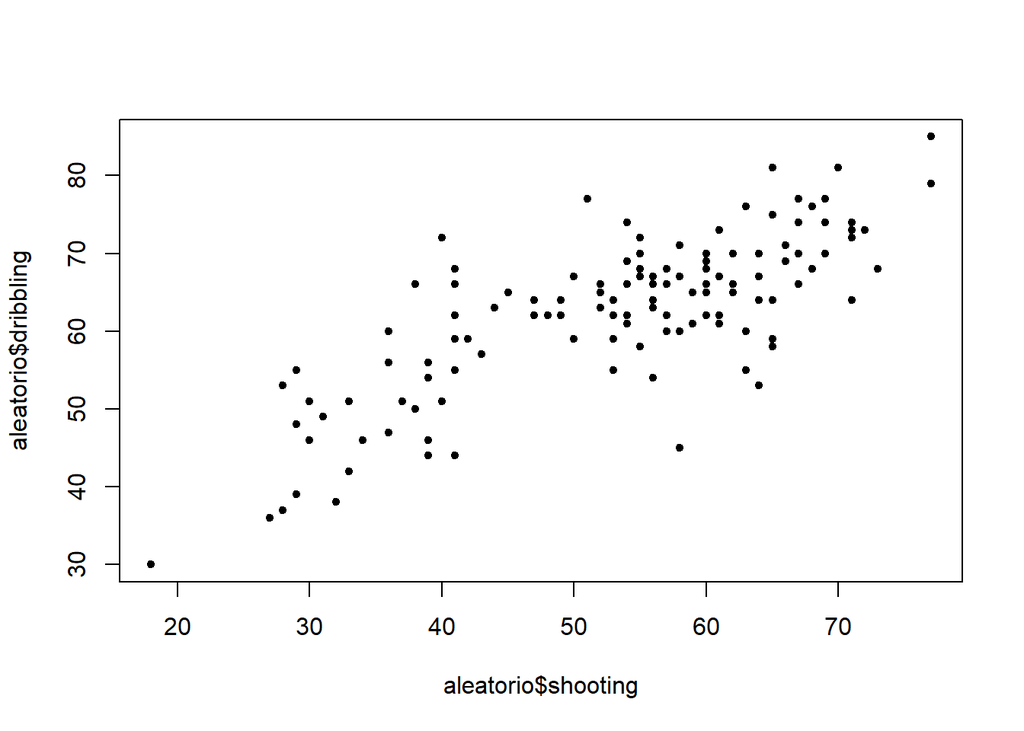

```r
plot(aleatorio$shooting, aleatorio$dribbling, pch=20)
```

Con etiquetas

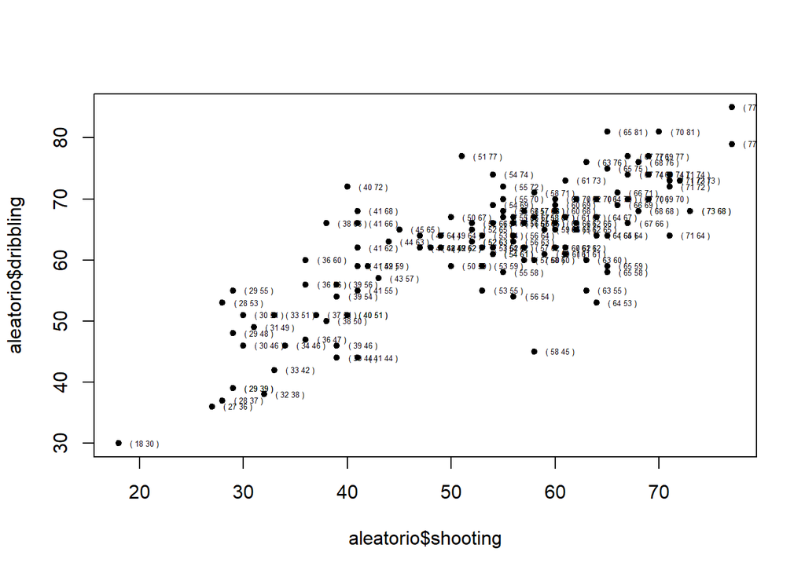

```r
plot(aleatorio$shooting, aleatorio$dribbling, pch=20)
text(aleatorio$shooting,
     aleatorio$dribbling,
     labels = paste("(",aleatorio$shooting, aleatorio$dribbling, ")"),
     pos = 4, cex = 0.4)
```

Observamos que los puntos generan una tendencia lineal.

## 2.2. Cálculo de los coeficientes de la recta de regresión.

Calculemos el coeficiente de correlación.

```r
cor(aleatorio$shooting, aleatorio$dribbling)
```

```
## [1] 0.7787402
```

Observamos que existe una relación lineal, no obstante, no es muy cercana a 1, lo cual quiere decir que no es una relación lineal muy fuerte.

Modelo (recta) de los puntos

```r
modelo <- lm(dribbling ~ shooting, data=aleatorio); modelo
```

```
##
## Call:
## lm(formula = dribbling ~ shooting, data = aleatorio)
##
## Coefficients:
## (Intercept)     shooting
##     29.7390       0.6131
```

De acuerdo a esto, el modelo de regresión lineal simple está dado por:

$$\hat{y}= 29.7390 +0.6131x$$

Vamos a representar en un plano el gráfico de dispersión y la recta usando ggplot.

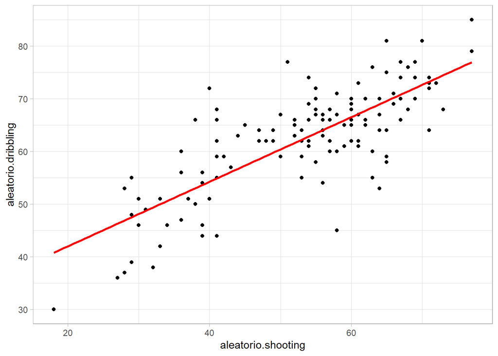

```r
ggplot(regresion_simple, aes(x=aleatorio.shooting, y= aleatorio.dribbling)) +
  geom_point() +
  geom_smooth(method='lm', formula=y~x, se=FALSE, col='red')+
  theme_light()
```

Cuando se hace un modelo de regresión lineal en R, este tiene cierta información oculta que es importante. Veamos

```r
names(modelo)
```

```
##  [1] "coefficients"  "residuals"     "effects"       "rank"
##  [5] "fitted.values" "assign"        "qr"            "df.residual"
##  [9] "xlevels"       "call"          "terms"         "model"
```

- **“coefficients”** : son los coeficientes del modelo

```r
modelo$coefficients
```

```
## (Intercept)    shooting
##  29.7389798   0.6130811
```

- **“fitted.values”**: valores ajustados, es decir, los valores sobre la recta

```r
modelo$fitted.values
```

```
##        1        2        3        4        5        6        7        8
## 61.61920 65.29768 70.81541 62.84536 49.35758 72.04158 62.84536 58.55379
##        9       10       11       12       13       14       15       16
## 54.26222 62.84536 59.77995 46.29217 55.48839 63.45844 54.87531 62.23228
##       17       18       19       20       21       22       23       24
## 48.13141 63.45844 64.68460 47.51833 70.20233 72.04158 54.87531 59.77995
##       25       26       27       28       29       30       31       32
## 72.65466 54.26222 64.07152 64.07152 62.84536 61.61920 67.75001 51.80990
##       33       34       35       36       37       38       39       40
## 56.10147 50.58374 76.94623 68.97617 66.52385 63.45844 73.88082 65.29768
##       41       42       43       44       45       46       47       48
## 63.45844 70.81541 48.13141 63.45844 65.91077 66.52385 47.51833 64.07152
##       49       50       51       52       53       54       55       56
## 73.26774 66.52385 49.97066 56.71455 65.29768 61.00612 67.13693 60.39304
##       57       58       59       60       61       62       63       64
## 69.58925 40.77444 46.90525 73.26774 52.42298 69.58925 61.61920 64.68460
##       65       66       67       68       69       70       71       72
## 66.52385 66.52385 60.39304 67.75001 68.97617 67.13693 46.90525 53.64914
##       73       74       75       76       77       78       79       80
## 64.68460 53.64914 67.75001 64.68460 68.97617 54.26222 70.81541 71.42850
##       81       82       83       84       85       86       87       88
## 53.03606 65.29768 70.81541 66.52385 62.84536 62.84536 67.13693 48.74449
##       89       90       91       92       93       94       95       96
## 54.87531 64.07152 53.03606 68.97617 54.87531 62.23228 68.36309 62.23228
##       97       98       99      100      101      102      103      104
## 65.29768 62.23228 67.13693 73.26774 47.51833 51.80990 51.80990 74.49390
##      105      106      107      108      109      110      111      112
## 54.87531 59.16687 69.58925 69.58925 74.49390 65.91077 53.64914 64.68460
##      113      114      115      116      117      118      119      120
## 64.68460 68.36309 47.51833 69.58925 57.32763 70.20233 59.77995 49.97066
##      121      122      123      124      125      126      127      128
## 58.55379 54.87531 71.42850 53.64914 64.07152 73.26774 76.94623 61.61920
##      129      130
## 68.36309 72.04158
```

- **“residuals”** : los errores o residuales $e_i= y-\hat{y}$

```r
modelo$residuals
```

```
##            1            2            3            4            5            6
##   1.38080252 -20.29768414   6.18458588  -1.84535970 -11.35757530   1.95842366
##            7            8            9           10           11           12
##  11.15464030   5.44620807  17.73777583   6.15464030   2.22004585 -10.29216975
##           13           14           15           16           17           18
##   3.51161361   3.54155919   4.12469472   1.76772141   2.86858692  -5.45844081
##           19           20           21           22           23           24
##   1.31539697  -8.51833197   0.79766699   4.95842366  13.12469472   4.22004585
##           25           26           27           28           29           30
##   8.34534255  -3.26222417  -0.07152192   1.92847808  -0.84535970   4.38080252
##           31           32           33           34           35           36
##   2.24999143   8.19010027   0.89853250  -4.58373752   8.05377479  -1.97617079
##           37           38           39           40           41           42
##  -4.52384635   6.54155919  -0.88081966   5.70231586   8.54155919  -4.81541412
##           43           44           45           46           47           48
##  -2.13141308   4.54155919  -0.91076524   2.47615365  -8.51833197   2.92847808
##           49           50           51           52           53           54
##   0.73226145   3.47615365  -7.97065641   6.28545139   1.70231586  15.99388363
##           55           56           57           58           59           60
##  -5.13692746   6.60696474 -10.58925190 -10.77443977   6.09474914  -1.26773855
##           61           62           63           64           65           66
##  -1.42298084 -11.58925190   3.38080252  -4.68460303   1.47615365  -1.52384635
##           67           68           69           70           71           72
##  -1.39303526  -1.75000857   1.02382921  -0.13692746  -9.90525086   2.35085694
##           73           74           75           76           77           78
##   3.31539697   0.35085694  -2.75000857   3.31539697 -15.97617079  -3.26222417
##           79           80           81           82           83           84
##  -0.81541412   4.57150477  12.96393805   1.70231586   3.18458588  -0.52384635
##           85           86           87           88           89           90
##   3.15464030  -1.84535970  -6.13692746   0.25550581  11.12469472  -1.07152192
##           91           92           93           94           95           96
##  -3.03606195  -4.97617079   7.12469472  -3.23227859 -13.36308968  -0.23227859
##           97           98           99          100          101          102
##  -5.29768414  -7.23227859   5.86307254  -9.26773855   0.48166803   4.19010027
##          103          104          105          106          107          108
##  -4.80989973  -6.49390077 -10.87530528   2.83312696   5.41074810  11.41074810
##          109          110          111          112          113          114
##  -6.49390077  -4.91076524  -7.64914306  -2.68460303   1.31539697  -8.36308968
##          115          116          117          118          119          120
##   7.48166803  -5.58925190   7.67237028  -1.20233301   2.22004585   1.02934359
##          121          122          123          124          125          126
##   3.44620807   0.12469472  -3.42849523  -9.64914306 -10.07152192  -0.26773855
##          127          128          129          130
##   2.05377479   1.38080252   7.63691032  -2.04157634
```

- Podemos representar lo anterior en una tabla

```r
data.frame(x=regresion_simple$aleatorio.shooting , y=regresion_simple$aleatorio.dribbling , y_adj=modelo$fitted.values , err=modelo$residuals)
```

```
##      x  y    y_adj          err
## 1   52 63 61.61920   1.38080252
## 2   58 45 65.29768 -20.29768414
## 3   67 77 70.81541   6.18458588
## 4   54 61 62.84536  -1.84535970
## 5   32 38 49.35758 -11.35757530
## 6   69 74 72.04158   1.95842366
## 7   54 74 62.84536  11.15464030
## 8   47 64 58.55379   5.44620807
## 9   40 72 54.26222  17.73777583
## 10  54 69 62.84536   6.15464030
## 11  49 62 59.77995   2.22004585
## 12  27 36 46.29217 -10.29216975
## 13  42 59 55.48839   3.51161361
## 14  55 67 63.45844   3.54155919
```

[output cut: 116 more lines]

Análisis del modelo : lm(y~x)

```r
summary(modelo)
```

```
##
## Call:
## lm(formula = dribbling ~ shooting, data = aleatorio)
##
## Residuals:
##     Min      1Q  Median      3Q     Max
## -20.298  -4.250   0.607   3.534  17.738
##
## Coefficients:
##             Estimate Std. Error t value Pr(>|t|)
## (Intercept) 29.73898    2.37673   12.51   <2e-16 ***
## shooting     0.61308    0.04365   14.04   <2e-16 ***
## ---
## Signif. codes:  0 '***' 0.001 '**' 0.01 '*' 0.05 '.' 0.1 ' ' 1
##
## Residual standard error: 6.44 on 128 degrees of freedom
## Multiple R-squared:  0.6064, Adjusted R-squared:  0.6034
## F-statistic: 197.2 on 1 and 128 DF,  p-value: < 2.2e-16
```

Residuales.

Esta parte contiene la información de los residuales.

```r
summary(modelo$residuals)
```

```
##    Min. 1st Qu.  Median    Mean 3rd Qu.    Max.
## -20.298  -4.250   0.607   0.000   3.534  17.738
```

Se observa que el mínimo y el máximo tienen signos contrarios. Además, se evidencia que la media está muy cerca de cero.

## 2.3. Analice las pruebas de hipótesis sobre los parámetros.

Ahora procedemos a verificar si a partir del modelo encontrado con datos de la muestra

$$\hat{y}= \hat{\beta}_0+\hat{\beta}_1 .x$$
podemos estimar la recta ideal de la población

$$y= \beta_0+\beta_1 .x$$
Para esto, tenemos dos pruebas de hipótesis

1. Prueba de hipótesis para el coefiente $\beta_0$

$$\begin{cases} H_0 \, : \: \beta_0 = 0 \\ H_1 \ : \: \beta_0 \neq 0 \end{cases}$$
En este caso, el p-value* es 2e-16, como es menor que $0.05$ entonces con un $95%$ de confianza podemos rechazar la hipótesis nula. Esto quiere decir que β0, que es el parámetro que se estima de la recta ideal de la población, es diferente de cero.

Lo anterior, indica que la recta ideal no pasa por el origen, sin embargo, esta prueba de hipótesis podría aceptarse y en este caso lo que estamos diciendo es que la recta ideal de la población pasa por el origen con un 95% de confianza.

2. Prueba de hipótesis para el coefiente $\beta_1$

$$\begin{cases} H_0 \, : \: \beta_1 = 0 \\ H_1 \ : \: \beta_1 \neq 0 \end{cases}$$
En este caso, el p-value* es 2.2e−16, como es menor que 0.05 entonces con un 95% de confianza podemos rechazar la hipótesis nula. Esto quiere decir que β1, que es el parámetro que se estima de la recta ideal de la población, es diferente de cero.

## 2.4. Identifique el coeficiente de determinación y analice la tabla ANOVA

Ajuste del modelo : Prueba F-ANOVA

Ahora procedemos a verificar que las diferencias entre los datos y las predicciones del modelo sean pequeñas.

La tabla anova, nos permite examinar la siguiente prueba de hipótesis

$$\begin{cases} H_0 \, : \, \text{el modelo lineal NO explica bien la respuesta} \\ H_1 \, : \, \text{el modelo explica bien la respuesta} \end{cases}$$
Lo que es equivalente a

$$\begin{cases} H_0 \, : \, \beta_1=0 \\ H_1 \, : \, \beta_1 \neq 0 \end{cases}$$

```r
anova(modelo)
```

```
## Analysis of Variance Table
##
## Response: dribbling
##            Df Sum Sq Mean Sq F value    Pr(>F)
## shooting    1 8179.4  8179.4  197.23 < 2.2e-16 ***
## Residuals 128 5308.2    41.5
## ---
## Signif. codes:  0 '***' 0.001 '**' 0.01 '*' 0.05 '.' 0.1 ' ' 1
```

## 2.5. ¿Es un buen modelo para el conjunto de datos?

De acuerdo con lo anterior, $p-value= 2.2 \times 10^{-16} \approx 0$, luego, rechazamos la hipótesis nula y por tanto el modelo explica bien la respuesta. Dado lo anterior, concluimos que el modelo tiene una capacidad predictiva significativa.

Análisis de residuos

verificaremos si se satisfacen las condiciones básicas el modelo de regresión.

## 2.6. Análisis de residuos.

### 2.6.1 Linealidad.

Lo primero que debemos ver es si las variables $x$ , $y$ tienen una relación lineal, para ello, revisamos la correlación y planteamos la prueba de hipótesis.

$$\begin{cases} H_0 \, : \, \rho =0 \quad \text{no existe relación lineal} \\ H_1 \, : \, \rho \neq 0 \quad \text{ sí existe relación lineal} \end{cases}$$
y usamos el test cor.test

```r
cor.test(regresion_simple$aleatorio.shooting,regresion_simple$aleatorio.dribbling)
```

```
##
##  Pearson's product-moment correlation
##
## data:  regresion_simple$aleatorio.shooting and regresion_simple$aleatorio.dribbling
## t = 14.044, df = 128, p-value < 2.2e-16
## alternative hypothesis: true correlation is not equal to 0
## 95 percent confidence interval:
##  0.7004802 0.8384941
## sample estimates:
##       cor
## 0.7787402
```

Como el $p-valor = 2.2e-16$ es menor que $0.05$ se rechaza la hipótesis nula y concluimos que existe una relación lineal.

### 2.6.1.1. Linealidad de los residuos.

Para verificar esta condición ya tenemos una idea importante de su cumplimiento por la relación lineal entre las variables por medio del cor.test. Sin embargo, para evaluarla revisemos la media de los residuos.

```r
residuos <- residuals(modelo)
```

```r
mean(residuos)
```

```
## [1] 1.969445e-16
```

Observemos que esta media es casi cero. Es un buen indicio de linealidad.

Esta situación también la podemos observar de los residuos: graficando **Valores ajustados vs Residuos** en R : **fitted.values vs residuals**, esto se hace con *plot(modelo, 1)*

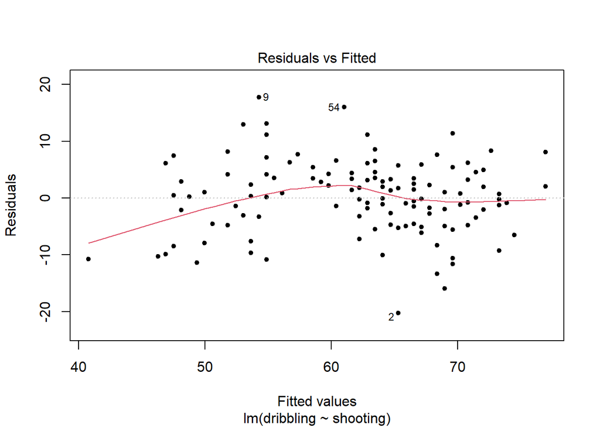

```r
plot(modelo, 1, pch=20)
```

### 2.6.2. Normalidad.

Para determinar la normalidad de los residuos podemos usar la instrucción plot(modelo, 2) o algún test de normalidad

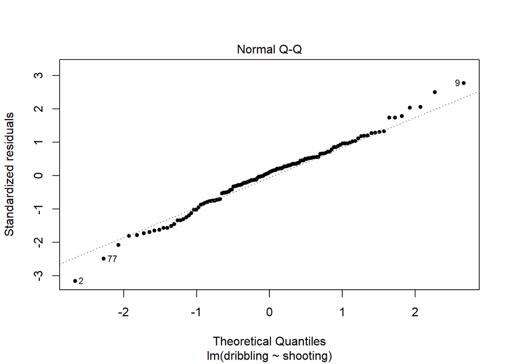

```r
plot(modelo, 2, pch=20)
```

El comportamiento de la gráfica es bueno, ya que los puntos están distribuidos cerca a la recta.

Podemos corroborar con un test. por ejemplo el de Kolmogorov-Smirnov ya que son más de 50 datos. Aplicamos el *lillie.test*

```r
lillie.test(residuos)
```

```
##
##  Lilliefors (Kolmogorov-Smirnov) normality test
##
## data:  residuos
## D = 0.062151, p-value = 0.2517
```

Como el $p-valor=0.2517$ es mayor que $\alpha=0.05$ no rechazamos la hipótesis nula, es decir, los residuos provienen de una distribución normal.

Examinamos las gráficas:

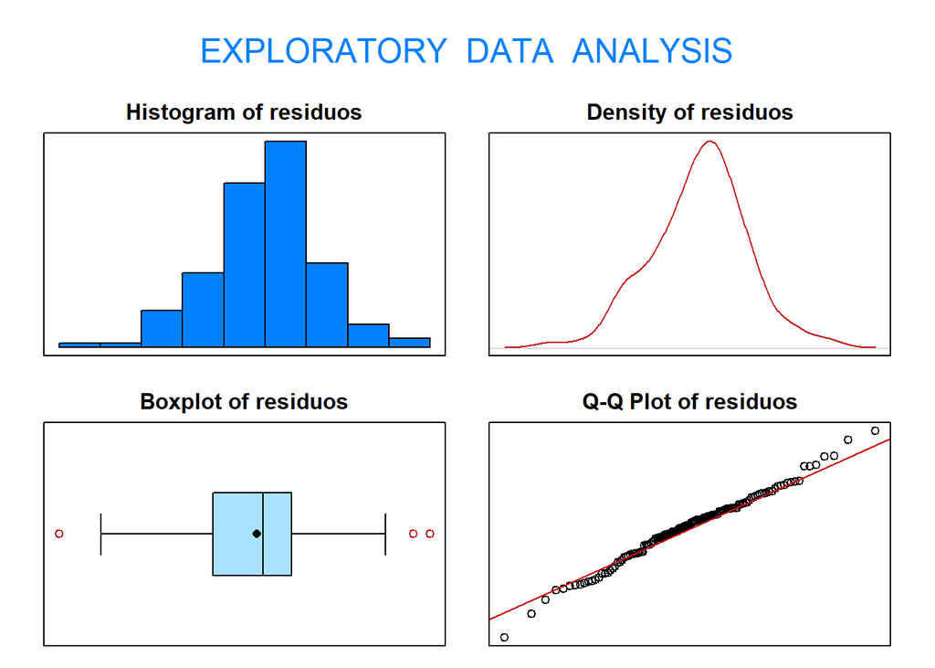

```
## Size (n)  Missing  Minimum   1st Qu     Mean   Median   TrMean   3rd Qu
##  130.000    0.000  -20.298   -4.250    0.000    0.607    0.009    3.534
##      Max    Stdev      Var  SE Mean   I.Q.R.    Range Kurtosis Skewness
##   17.738    6.415   41.149    0.563    7.784   38.036    0.391   -0.182
## SW p-val
##    0.517
```

```r
eda(residuos)
```

### 2.6.3. Homocedasticidad.

Para revisar la homocedasticidad podemos utilizar la gráfica de valores ajustados vs residuos.Realizamos el test de *breuch-pagan* para el siguiente planteamiento de hipótesis

$$\begin{cases} H_0 \, : \; \text{los datos son homocedásticos} \\ H_1 \, : \, \text{los datos son heterocedásticos} \end{cases}$$

```r
bptest(modelo)
```

```
##
##  studentized Breusch-Pagan test
##
## data:  modelo
## BP = 2.0678, df = 1, p-value = 0.1504
```

Como el $p-valor=0.1504$ es mayor que $\alpha=0.05$ no rechazamos la hipótesis nula, es decir, se concluye la homocedásticidad de los datos.

Gráficamente, podemos usar plot(modelo,3)

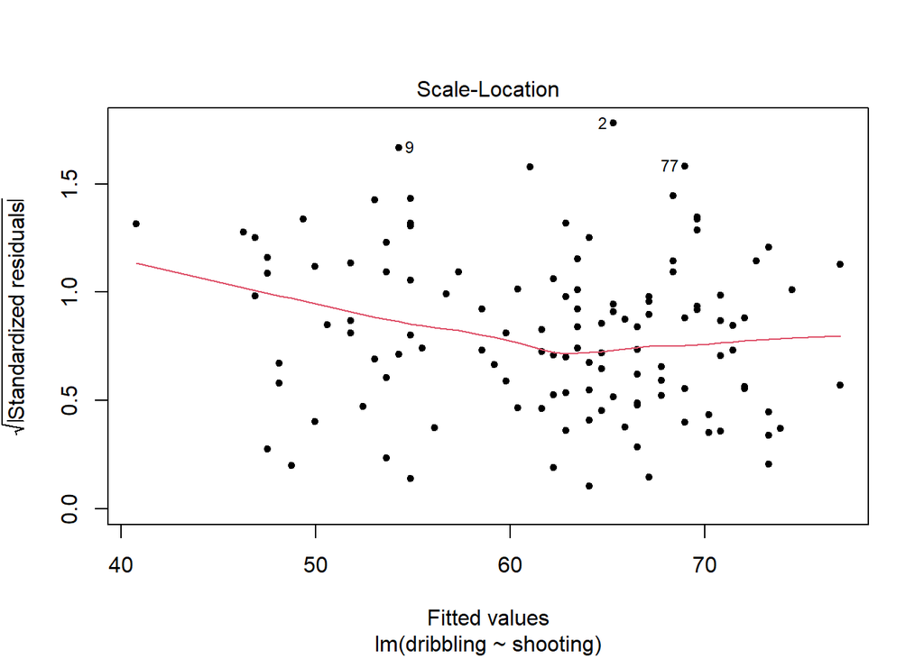

```r
plot(modelo, 3, pch = 20)
```

### 2.6.4. Independencia de los residuos.

Para comprobar la no correlación para los residuos estudentizados del modelo ajustado. Se realiza a través del Test de Durbin-Watson (asume bajo la hipótesis nula que no existe correlación). La función *dwtest()* realiza este contraste directamente sobre los residuos estudentizados.

$$\begin{cases} H_0 \, : \; \text{los errores no estan correlacionados} \\ H_1 \, : \, \text{los errores están correlacionados} \end{cases}$$
Aplicando el test *dwtest* de la librería *lmtest* tenemos

```r
dwtest(modelo)
```

```
##
##  Durbin-Watson test
##
## data:  modelo
## DW = 2.0035, p-value = 0.5104
## alternative hypothesis: true autocorrelation is greater than 0
```

el $p-valor=0.5104$ es mayor que $0.05$ no rechazamos la hipótesis nula y por tanto los residuos no están correlacionados, es decir, son independientes.

Gráficamente podemos verlo de dos maneras. Haciendo el gráfico de residuales.

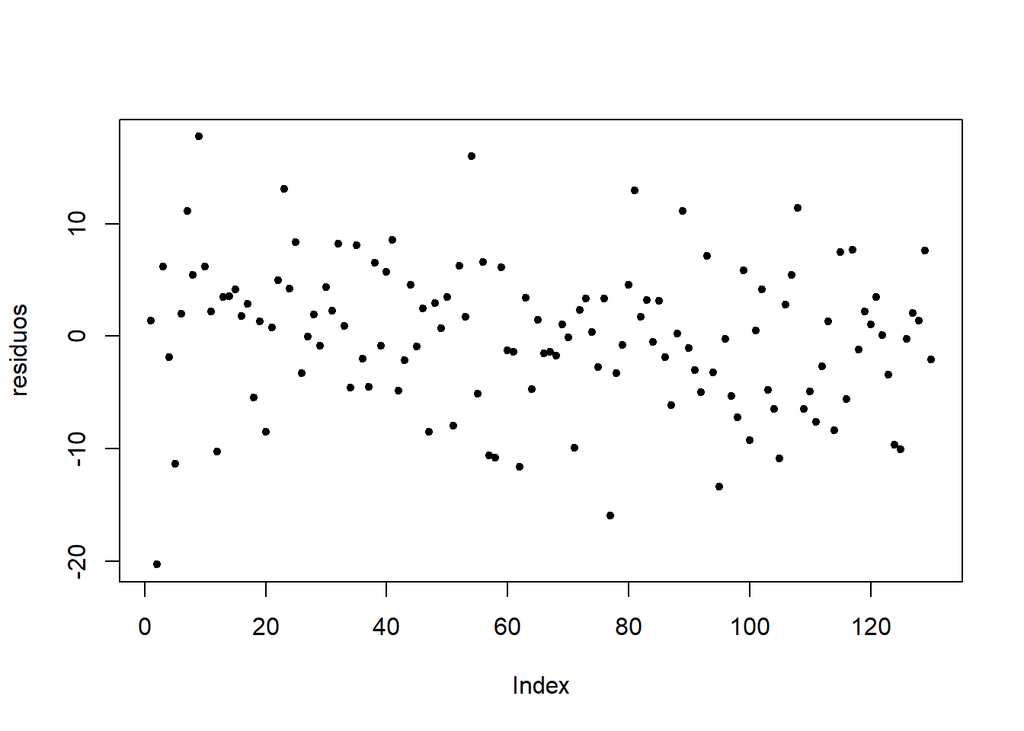

```r
plot(residuos, pch=20)
```

Se observa que no hay patrón en los datos y esto son indicios de independencia.

También podemos revisar la siguiente gráfica acf

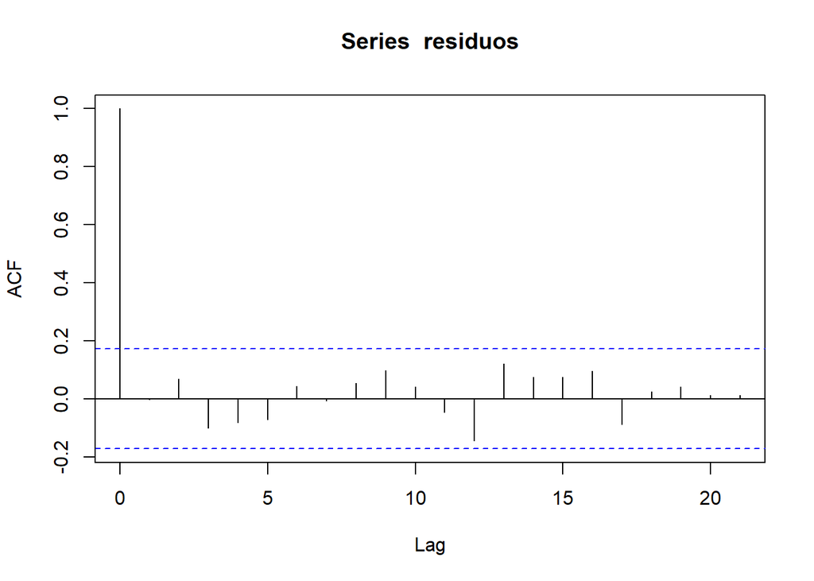

```r
acf(residuos)
```

Observamos que a medida que avanzamos en el eje $x$, las lineas verticales no se salgan de la franja. Como observamos que esto ocurre, los residuales son independientes.

Como resumen de las gráficas anteriores podemos tenerlas en una sola.

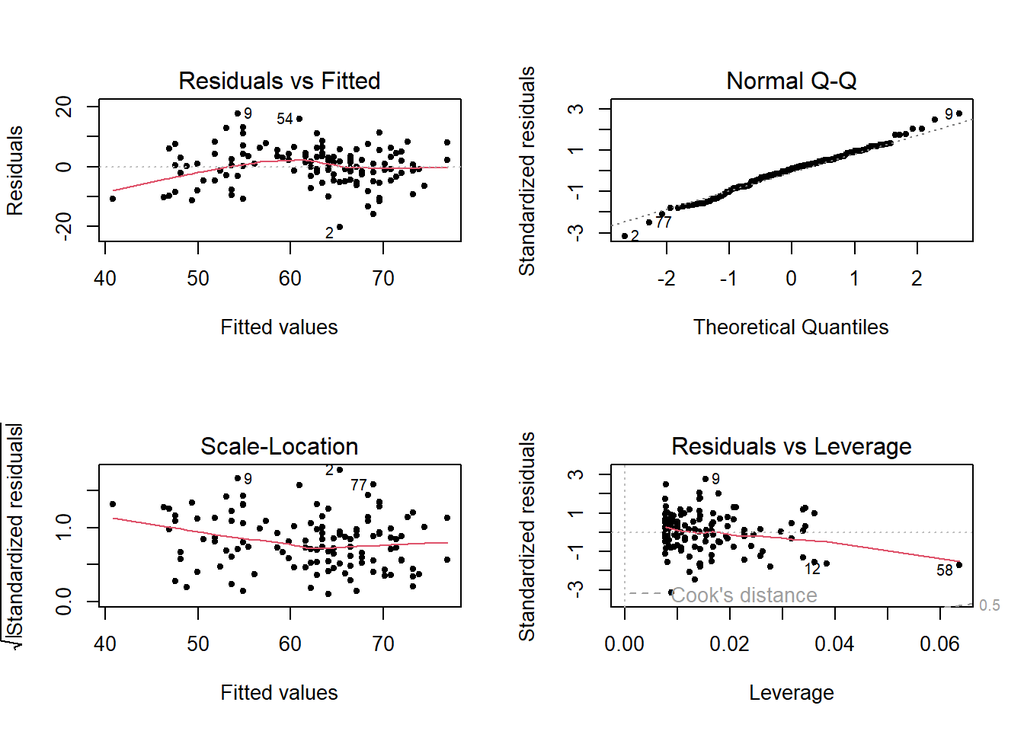

```r
par(mfrow=c(2,2))
plot(modelo, pch=20)
```

## 2.7. Gráfica: residual vs leverage.

Vamos a examinar la gráfica y su información

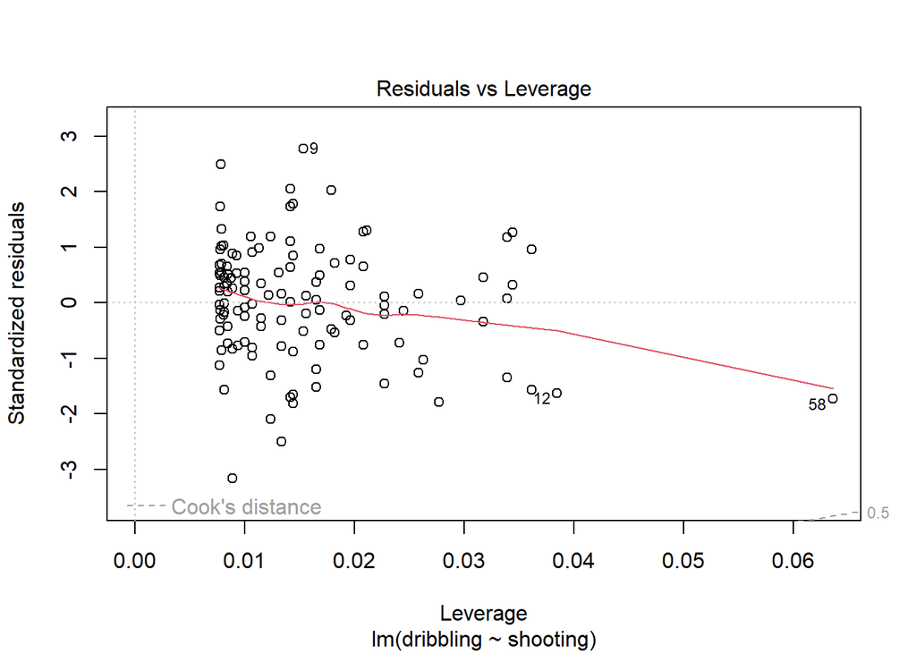

```r
plot(modelo, 5)
```

Esta gráfica es usada para identificar los valores atípicos y los puntos de apalancamiento. Donde los **Valores atípicos** son observaciones con residuos estandarizados mayores que +/- 2, las cuales se encuentran fuera de las líneas horizontales de referencia de la gráfica. Valores numéricamente distantes del resto de los datos. Y los **Puntos de apalancamiento (influyentes)** son observaciones con valores de apalancamiento por fuera de la distancia de Cook. Estos valores tienen bastante incidencia en el modelo, debido a que afectan notablemente la pendiente del modelo.

Para determinar los valores atípicos , podemos usar, el método **Bonferroni**

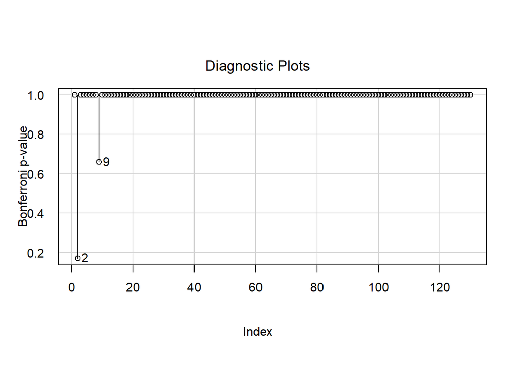

```r
infIndexPlot(modelo, vars="Bonf", las = 1)
```

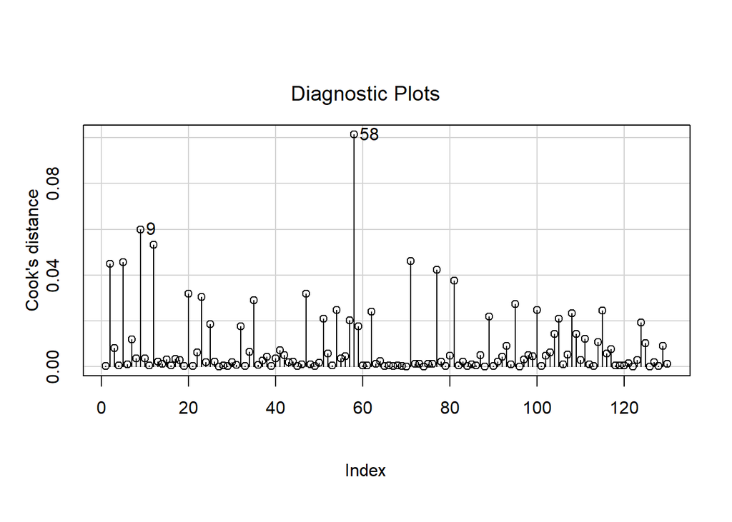

```r
influenceIndexPlot(modelo, vars="Cook")
```

Los valores influyentes son aquellos que sobrepasan el umbral de $1$ en la distancia de *Cook*.

## 2.8. Gráfica de intervalos de confianza y predicción del modelo.

Estimación de la regresión lineal.

Para el ejercicio trabajado, evaluaremos la **respuesta media** para un jugador cuyo shooting sea 46, (valor que no pertenece al conjunto de valores dados).

Recordemos que la regresión lineal estaba está dada por:

$$\hat{y}= 29.7390 +0.6131x$$
luego, si $x_0=46$, entonces $\hat{y}=29.7390 +0.6131(46)= 57.94$

Comprobamos lo anterior en R , mediante la instrucción *predict*

```r
nuevo <- data.frame(shooting=c(46))
ic = predict(modelo, nuevo, interval = "confidence", level = 0.95); ic
```

```
##        fit      lwr      upr
## 1 57.94071 56.67478 59.20664
```

Vemos que en promedio, un jugador cuyo shooting sea de 46, implica que su dribbling será de 57.94, entre un intervalo de 56.67 y 59.20 y con un nivel de confianza del 95%.

Además podemos graficar los intervalos de confianza de todos los valores.

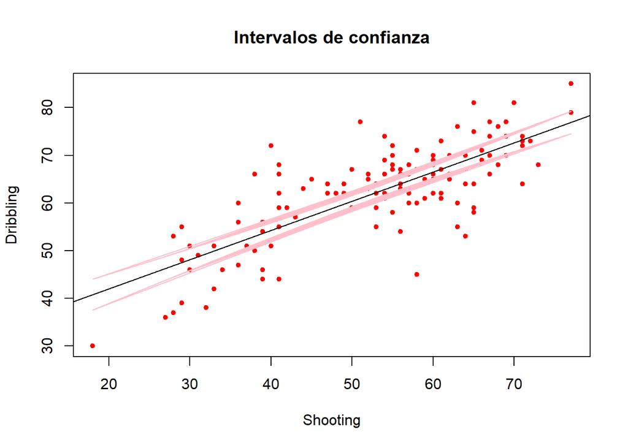

```r
plot(aleatorio$shooting, aleatorio$dribbling, xlab = "Shooting", ylab = "Dribbling", main= "Intervalos de confianza", col="red", pch=20)
abline(modelo)
intconf <- predict(modelo, aleatorio, interval = "confidence")
lines(aleatorio$shooting, intconf[,2], lty=1, col="pink")
lines(aleatorio$shooting, intconf[,3], lty=1, col="pink")
```

Ahora procedemos a graficar el intervalo de predicción.

```r
nuevo1 <- data.frame(shooting=c(46))
ip <- predict(modelo, nuevo1, interval = "prediction", level=c(0.90, 0.95, 0.99) ) ; ip
```

```
##           fit      lwr      upr
## [1,] 57.94071 47.21849 68.66293
## [2,] 57.94071 45.13580 70.74562
## [3,] 57.94071 41.01921 74.86221
```

Podemos gráficar los intervalos de predicción

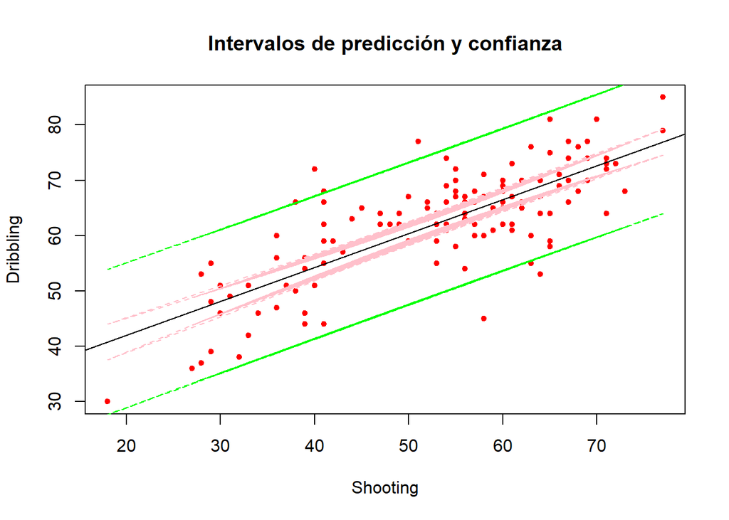

```r
plot(aleatorio$shooting, aleatorio$dribbling, xlab = "Shooting", ylab = "Dribbling", main= "Intervalos de predicción y confianza", col="red", pch=20)

abline(modelo)

intconf1 <- predict(modelo, aleatorio, interval = "confidence", level = 0.95)

lines(aleatorio$shooting, intconf1[,2], lty=2, col="pink")
lines(aleatorio$shooting, intconf1[,3], lty=2, col="pink")

ipp <- predict(modelo, aleatorio, interval = "prediction", level=0.95)
lines(aleatorio$shooting, ipp[,2], lty=2, col="green")
lines(aleatorio$shooting, ipp[,3], lty=2, col="green")
```

Se evidencia que la recta del modelo se ajusta muy bien al intervalo de confianza, y además, la mayoría de los puntos están comprendidos dentro del intervalo de predicción, lo cual da cuenta de que el modelo tiene una capacidad predictiva significativa.